# More R Markdown

Andrew Ba Tran

This is from the [sixth chapter](https://learn.r-journalism.com/en/publishing/more_rmarkdown/more-rmarkdown/) of [learn.r-journalism.com](https://learn.r-journalism.com/).

Let’s create some R Markdown files.

Make sure your working directory is set.

If you’re not working with the learn-chapter-6-master [folder](https://github.com/r-journalism/learn-chapter-6) you downloaded with **usethis**, download your files to a folder called *data*.

If you get lost, the .Rmd files can be found in the [lesson repo](https://github.com/r-journalism/learn-chapter-6).

We’ll start out by generating a report with Boston city payroll data.

### Datatables

1. Create a new R Markdown file and call it **Chunk 1**.
   - Leave author blank for these exercises

The top of your file (currently called *Untitled 1*) should look like this:

```
---
title: "Chunk 1"
output: html_document
---
```

and then that will be followed by the dummy code.

Delete everything beneath the YAML code.

Replace it with [this code](https://gist.github.com/andrewbtran/1af1ad6a9059e2521de53976e4934a1c):

Save the file as 01_chunk.Rmd and click the knit button.

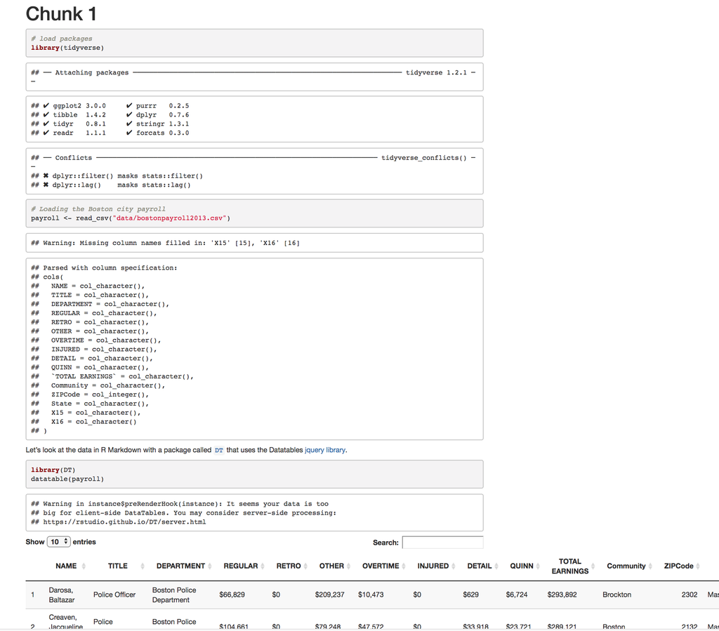

Yikes, okay, that’s way too much.

### Hide warnings, messages

We can hide those console messages adding `warning=F` and `message=F` by the R code chunk labels.

Create a new R Markdown file and call it **Chunk 2**.

Type [the code](https://gist.github.com/andrewbtran/fb45ca115207549ce6d136917bf8d24c) in below.

The new code can be found on lines 6 and 16.

Save the file as 02_chunk.Rmd and click the knit button.

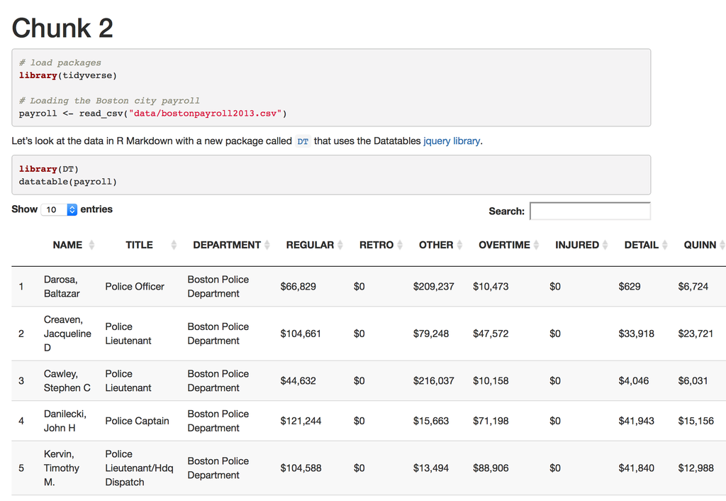

Now that’s much more readable and gets to the data quicker.

### Hide code

If the person you’re sharing this with has no interest in the code and only the quick results, use `echo=F` to hide the chunk of code and just display the output. It’s on line 8.

We’ll also narrow down the variables selected so the table isn’t way too wide.

Create a new R Markdown file and call it **Chunk 3**.

Type [the code](https://gist.github.com/andrewbtran/8784cf26ad18309a17687d3e416541ed) in below.

The new code can be found on 8 and 17.

Save the file as 03_chunk.Rmd and click the knit button.

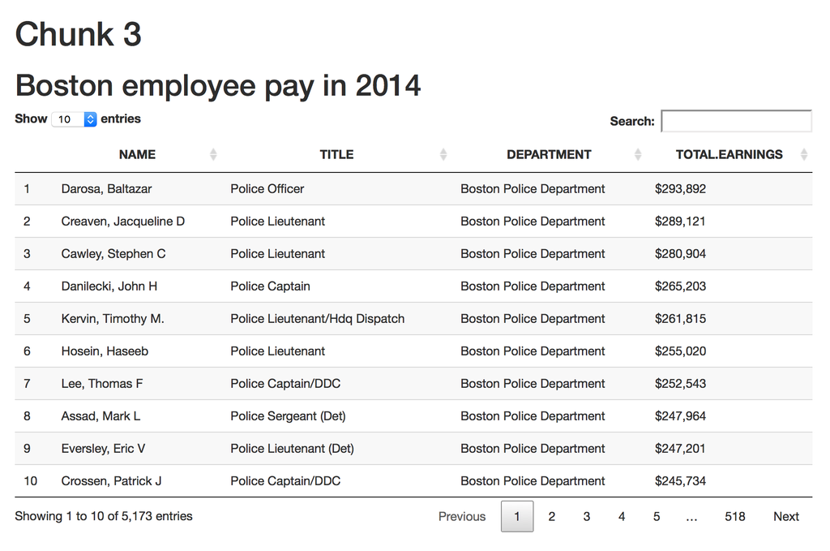

### Inline R code

Embed lines of R code within the markdown narrative with

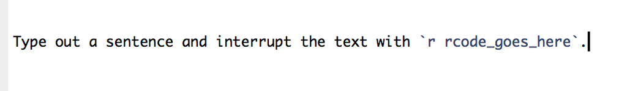

Create a new R Markdown file and call it **Chunk 4**.

Type [the code](https://gist.github.com/andrewbtran/cad0673cdd4cf527f6781a94f597bd0c) in below.

The new code can be found on line 29 and 31.

Save the file as 04_chunk.Rmd and click the knit button.

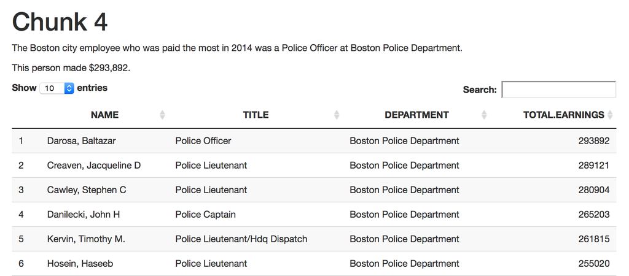

This type of self-generating analysis is important because if you get the next year of payroll data, running this report will sub in the new city employee who makes the most money automatically.

### Pretty tables

Make pretty tables with the **knitr** package and the `kable()` function.

Create a new R Markdown file and call it **Chunk 5**.

Type [the code](https://gist.github.com/andrewbtran/1751cc2e09acae6f1778f481b86b9a17) in below.

The new code can be found all the way down on line 60 and 61.

Save the file as 05_chunk.Rmd and click the knit button.

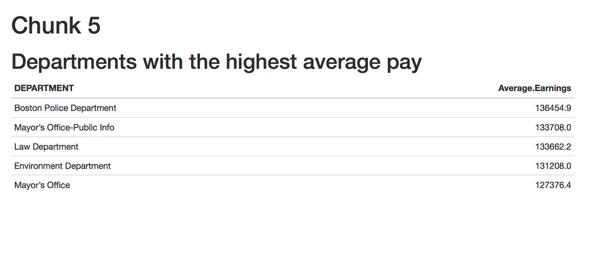

### Change theme and style

Change the appearance and style of the HTML document by changing the theme up top.

Options from the [Bootswatch](http://bootswatch.com/) theme library includes:

- `default`
- `cerulean`
- `journal`
- `cosmo`

highlights (for the code syntax)

- `tango`
- `pygments`
- `kate`

Create a new R Markdown file and call it **Chunk 6**.

Type [the code](https://gist.github.com/andrewbtran/ccbdf93edfbf2d700aafa2eaea39e6f3) in below.

The new code is at the top in the YAML section.

Save the file as 06_chunk.Rmd and click the knit button.

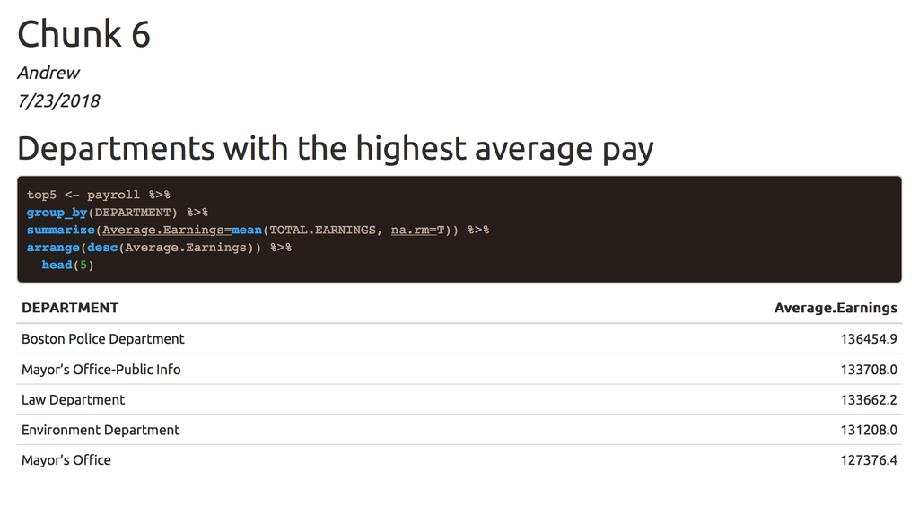

### Table of contents

Add a floating table of contents by changing `html_document` to `toc: true` and `toc_float: true`.

Create a new R Markdown file and call it **Chunk 7**.

Type [the code](https://gist.github.com/andrewbtran/59cebe7576e99a7773f3e694b0f0bb3b) in below.

The new code is at the top in the YAML section.

Save the file as 07_chunk.Rmd and click the knit button.

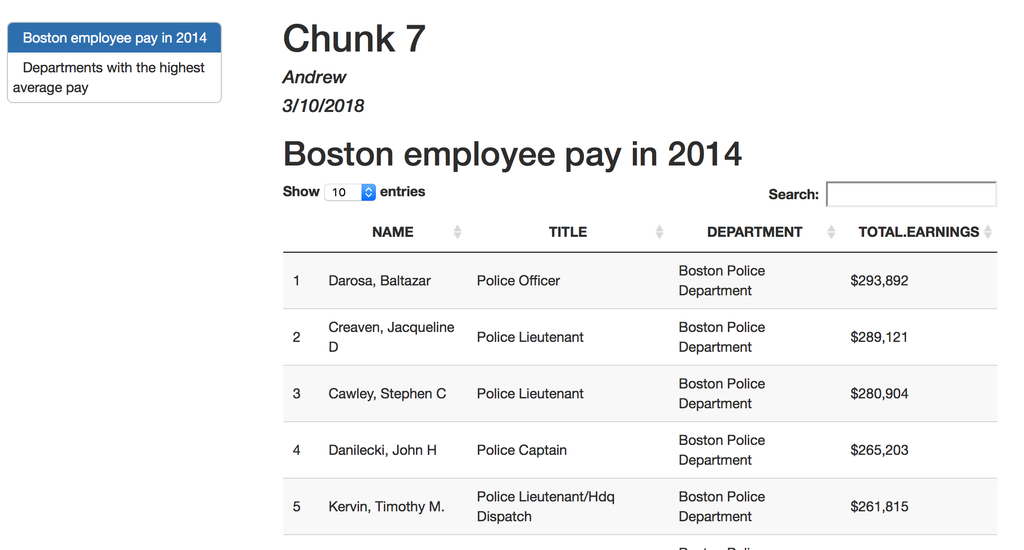

### Next steps?

Exporting as a PDF will require LaTex installed first * Get it from [latex-project.org](https://www.latex-project.org/get/) or [MacTex](http://www.tug.org/mactex/)

Check out [all the features](http://rmarkdown.rstudio.com/html_document_format.html#overview) of R Markdown at RStudio

**Publish your results to Github pages**